# Severe Weather Events and its Effects on Population Health and the Economy

d-muenter

## Synopsis

In this report we aim to describe which types of severe weather events are most harmful with respect to population health and which have the greatest economic consequences to allow for better allocation of resources for different types of events. To investigate these questions, we obtained data from the U.S. National Oceanic and Atmospheric Administration’s (NOAA) storm database which tracks characteristics of major storms and weather events in the Unites States, including when and where they occur, as well as estimates of any fatalities, injuries, and property damage.

## Data Processing

The data was downloaded from https://d396qusza40orc.cloudfront.net/repdata%2Fdata%2FStormData.csv.bz2 on Jan. 09, 2021 where it came in the form of a csv file compressed via the bzip2 algorithm. We then read in that data.

```r
stormdata <- read.csv("repdata_data_StormData.csv.bz2")
```

When looking at the structure of the dataset, we can see that there are 902,297 observations of 37 variables.

```r
str(stormdata)
```

```
## 'data.frame':    902297 obs. of  37 variables:
##  $ STATE__   : num  1 1 1 1 1 1 1 1 1 1 ...
##  $ BGN_DATE  : chr  "4/18/1950 0:00:00" "4/18/1950 0:00:00" "2/20/1951 0:00:00" "6/8/1951 0:00:00" ...
##  $ BGN_TIME  : chr  "0130" "0145" "1600" "0900" ...
##  $ TIME_ZONE : chr  "CST" "CST" "CST" "CST" ...
##  $ COUNTY    : num  97 3 57 89 43 77 9 123 125 57 ...
##  $ COUNTYNAME: chr  "MOBILE" "BALDWIN" "FAYETTE" "MADISON" ...
##  $ STATE     : chr  "AL" "AL" "AL" "AL" ...
##  $ EVTYPE    : chr  "TORNADO" "TORNADO" "TORNADO" "TORNADO" ...
##  $ BGN_RANGE : num  0 0 0 0 0 0 0 0 0 0 ...
##  $ BGN_AZI   : chr  "" "" "" "" ...
##  $ BGN_LOCATI: chr  "" "" "" "" ...
##  $ END_DATE  : chr  "" "" "" "" ...
##  $ END_TIME  : chr  "" "" "" "" ...
##  $ COUNTY_END: num  0 0 0 0 0 0 0 0 0 0 ...
```

[output cut: 23 more lines]

To make working with this large dataset easier, we extract only those columns that are relevant to the questions we are trying to answer. Those questions are which **types of events** are most harmful to **population health** and have the greatest **economic consequences**.  
Therefore, we include the EVTYPE, FATALITIES, INJURIES, PROPDMG, PROPDMGEXP, CROPDMG and CROPDMGEXP columns in our new dataset. We also include the STATE, BGN_DATE and BGN_TIME columns in case we need them for our analysis.

```r
data <- stormdata[,c(2:3,7:8,23:28)]
```

## Results

Because missing values can often be a problem when analyzing data, we check for missing values and see that there are none.

```r
mean(is.na(data))
```

```
## [1] 0
```

Because there are 985 different event types we need to look at the different variables to see which of these types of events have a considerable effect on health and economic parameters.

```r
length(unique(data$EVTYPE))
```

```
## [1] 985
```

### Effects on Population Health

**Fatalities**  
First, we want to find out what types of events caused the most fatalities. To do this, we create a vector containing all the different types of events ranked by the number of fatalities they caused.

```r
fatal <- sort(with(data, tapply(FATALITIES, EVTYPE, sum)), decreasing=T)
sum(fatal)
```

```
## [1] 15145
```

```r
length(fatal[fatal!=0])
```

```
## [1] 168
```

```r
fatal <- fatal[fatal!=0]  ## ignore types of events that didn't cause any fatalities
summary(fatal)
```

```
##    Min. 1st Qu.  Median    Mean 3rd Qu.    Max.
##    1.00    1.00    4.00   90.15   19.75 5633.00
```

We can see that there are a total of 15,145 fatalities recorded. Out of the 985 different types of events only 168 caused any fatalities. We can also see that only 42 different types of events (upper quadrant) caused more than 19 fatalities.

**Injuries**  
Next, we take a look at what types of events caused the most injuries. Again, we create a vector containing all the different types of events ranked by the number of injuries they caused.

```r
injur <- sort(with(data, tapply(INJURIES, EVTYPE, sum)), decreasing=T)
sum(injur)
```

```
## [1] 140528
```

```r
length(injur[injur!=0])
```

```
## [1] 158
```

```r
injur <- injur[injur!=0]  ## ignore types of events that didn't cause any injuries
summary(injur)
```

```
##    Min. 1st Qu.  Median    Mean 3rd Qu.    Max.
##     1.0     2.0    12.5   889.4    78.5 91346.0
```

Here we can see that there are a total of 140,528 injuries recorded. Interestingly, out of the 985 different types of events only 158 caused any injuries which is less than the types of events that caused fatalities. In this case, we can see that 25 % of those 158 different types of events caused more than 78 injuries.

**Result**  
Let’s combine these findings in order to determine which types of events are most harmful with respect to population health.

```r
harmfulevents <- unique(c(names(fatal[1:10]), names(injur[1:10])))
healthdata <- data[data$EVTYPE %in% harmfulevents,]
nrow(healthdata) / nrow(data)
```

```
## [1] 0.856361
```

We created a dataset including only 13 different types of events which were either in the “top 10” for fatalities or in the “top 10” for injuries or (for most of them) were in both of these “top 10”. We can also see that more than 85 % of all observations belong to these 13 types of events.  
Next, we plot these 13 types of events and the corresponding fatalities and injuries to visualize their effects on population health.

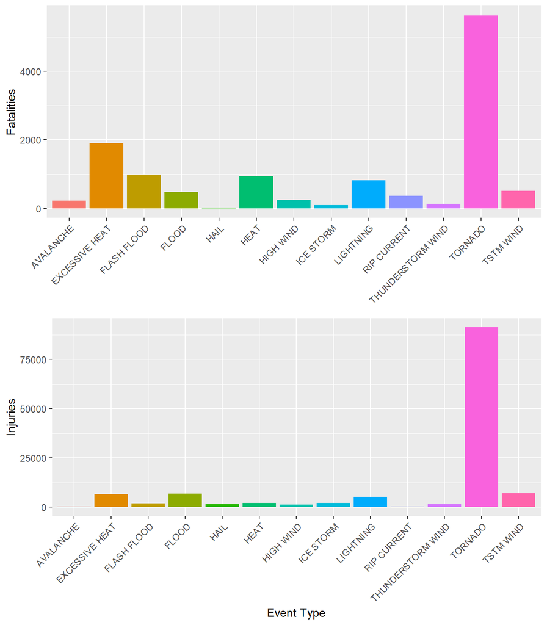

```r
library(ggplot2)
fatal_plot <- ggplot(healthdata, aes(EVTYPE, FATALITIES)) +
    geom_col(aes(fill=EVTYPE)) + guides(fill=FALSE) +
    theme(axis.text.x=element_text(angle=45, hjust=1)) +
    labs(x=NULL, y="Fatalities")
injur_plot <- ggplot(healthdata, aes(EVTYPE, INJURIES)) +
    geom_col(aes(fill=EVTYPE)) + guides(fill=FALSE) +
    theme(axis.text.x=element_text(angle=45, hjust=1)) +
    labs(x="Event Type", y="Injuries")
library("gridExtra")
grid.arrange(fatal_plot, injur_plot, nrow=2)
```

Here we can see that tornados are the major cause for fatalities and injuries. Especially when looking at events that cause a lot of fatalities, excessive heat and heat, flash floods and lightning seem to be the types of severe weather events (apart from tornados) that cause the biggest threat to the population.

### Economic Consequences

In this section we want to look at property damage and crop damage caused by different types of severe weather events. In order to find out what amount of damage was caused, we need to multiply the PROPDMG and CROPDMG variables by the PROPDMGEXP and CROPDMGEXP variables respectively. Because for some of the possible values of PROPDMGEXP and CROPDMGEXP it is unclear what exactly they mean and because the majority of all observations have one of a few more clear values, we take only those values into consideration where it is clear what they mean.

```r
table(data$PROPDMGEXP)
```

```
##
##             -      ?      +      0      1      2      3      4      5      6
## 465934      1      8      5    216     25     13      4      4     28      4
##      7      8      B      h      H      K      m      M
##      5      1     40      1      6 424665      7  11330
```

```r
table(data$CROPDMGEXP)
```

```
##
##             ?      0      2      B      k      K      m      M
## 618413      7     19      1      9     21 281832      1   1994
```

If PROPDMGEXP/CROPDMGEXP is equal to either “h”/“H”, “k”/“K”, “m”/“M” or “b”/“B”, we multiply PROPDMG/CROPDMG by either hundred, thousand, million or billion. If it is not equal to any of those values, PROPDMG/CROPDMG stays as it is.

```r
i <- 1
for (i in 1:nrow(data)) {
  ## Property damage
  if(data$PROPDMGEXP[i] == "H" | data$PROPDMGEXP[i] == "h"){
      data$PROPDMG[i] <- data$PROPDMG[i] * 100
  } else if (data$PROPDMGEXP[i] == "K" | data$PROPDMGEXP[i] == "k") {
    data$PROPDMG[i] <- data$PROPDMG[i] * 1000
  } else if (data$PROPDMGEXP[i] == "M" | data$PROPDMGEXP[i] == "m") {
    data$PROPDMG[i] <- data$PROPDMG[i] * 1000000
  } else if (data$PROPDMGEXP[i] == "B" | data$PROPDMGEXP[i] == "b") {
    data$PROPDMG[i] <- data$PROPDMG[i] * 1000000000
  }
  ## Crop damage
  if(data$CROPDMGEXP[i] == "H" | data$CROPDMGEXP[i] == "h"){
      data$CROPDMG[i] <- data$CROPDMG[i] * 100
  } else if (data$CROPDMGEXP[i] == "K" | data$CROPDMGEXP[i] == "k") {
    data$CROPDMG[i] <- data$CROPDMG[i] * 1000
  } else if (data$CROPDMGEXP[i] == "M" | data$CROPDMGEXP[i] == "m") {
    data$CROPDMG[i] <- data$CROPDMG[i] * 1000000
  } else if (data$CROPDMGEXP[i] == "B" | data$CROPDMGEXP[i] == "b") {
    data$CROPDMG[i] <- data$CROPDMG[i] * 1000000000
  }
}
```

Next we sort the different types of events by how much combined damage (property and crop) they caused.

```r
data$damage <- data$PROPDMG + data$CROPDMG
damagingevents <- sort(with(data, tapply(damage, EVTYPE, sum)), decreasing=T)
length(damagingevents[damagingevents!=0])
```

```
## [1] 431
```

```r
length(damagingevents[damagingevents!=0]) / length(damagingevents)
```

```
## [1] 0.4375635
```

```r
damagingevents <- damagingevents[damagingevents!=0] ## ignore types of events that didn't cause any damage
summary(damagingevents)
```

```
##      Min.   1st Qu.    Median      Mean   3rd Qu.      Max.
## 0.000e+00 1.500e+04 2.215e+05 1.105e+09 6.188e+06 1.503e+11
```

We can see that out of the 985 different types of events 431, or about 44 %, caused any damage (that was recorded). For those 431 types of events we can further see that half of them caused damage of more than $221,500 and the upper 25 % caused damage of more than $6.19 Million.  
Finally, we create a plot to look at the 10 most damaging types of events in terms of their economic consequences.

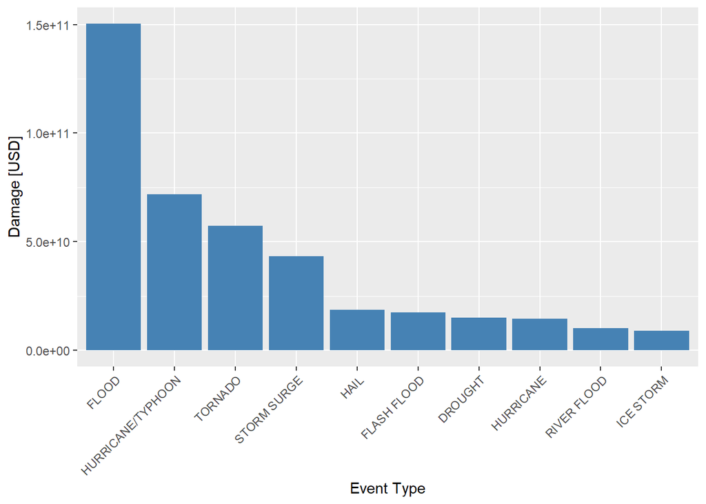

```r
plotdata <- as.data.frame(damagingevents[1:10])
names(plotdata) <- "damage"
ggplot(plotdata, aes(reorder(rownames(plotdata), -damage), damage)) +
  geom_col(fill="steelblue") + labs(x="Event Type", y="Damage [USD]") +
  theme(axis.text.x=element_text(angle=45, hjust=1))
```

To conclude, we can say that floods have the greatest economic consequences followed by hurricanes and typhoons, tornadoes, storm surges and hail.